# Digit Recognizer by Neural Network

## Intorduction

This algorithm is for a [kaggle competition](https://www.kaggle.com/c/digit-recognizer) to take an image of a handwritten single digit, and determine what that digit is. The data used is [MNIST data](https://www.kaggle.com/c/digit-recognizer/data).

The data include 42000 image of hand-drawn digits. Each image is 28 pixels in height and 28 pixels in width, for a total of 784 pixels.

Let’s visualize some sample data:

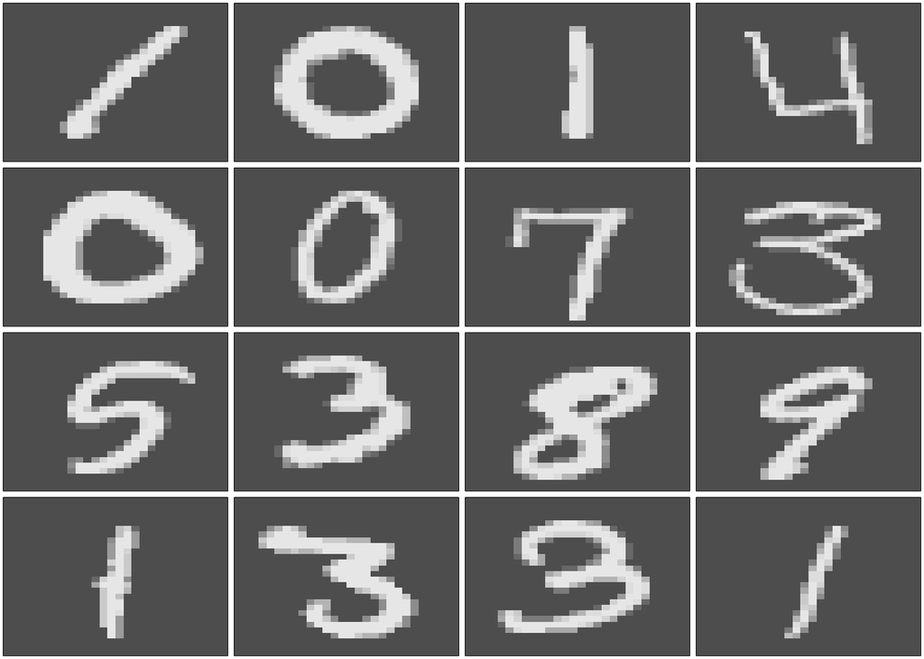

```r
require(graphics)

flip = function(x) {
  xx=matrix(0,nrow(x),ncol(x))
  for (i in (1:nrow(x))){
    xx[i,] = rev(x[i,])}
  return(xx)}

sample_plot = function(x,n) {
  xx = list()
  par(mfrow=c(sqrt(n), sqrt(n)),mar=rep(0.2,4))
  for (i in 1:n) {
    temp = as.numeric(x[i,])
    temp = matrix(temp,28,28)
    xx[[i]] = flip(temp)
    image(z=xx[[i]], col=gray.colors(12),xaxt='n',yaxt='n',ann=FALSE)
  }}

sample_p <- read.csv("sample.csv", header=TRUE)[,-1]
sample_p = sample_p[,-1]
sample_plot(sample_p,16)
```

## Neural Network Algorithm

### Forward Propagation

The model used is one level Artifical Neural Network(ANN). The superscript number in brack of each variable represent the level. In this model(one level ANN), 0 represent input level, 1 represent hidden level, 2 represent output level. $X^{(0)}$ is the raw data(a image of hand-drawn digit), a 1 row 784 columns matrix. $f_{\theta}(a)$ is a sigmoid function。$a$ hidden level variables，$z$ is the hidden level data and the output of sigmoid function ,$\Theta^{(l)}_0$ are the biased terms in input level and output level. $\widehat{Y}$ is the output and predicted values，a 1 row 10 columns matrix range between 0 and 1. When the maximum value lie in the third column, the prediction of the image would be 3.

$a^{(1)} = \Theta^{(1)}_0+X^{(0)}(\Theta^{(1)})^T$

$z^{(1)} = f_{\theta}(a^{(1)})$

$a^{(2)} = \Theta^{(2)}_0+z^{(1)}(\Theta^{(2)})^T$

$\hat{Y} = f_{\theta}(a^{(2)})$

Here is structure of one hidden layer Neural Network(with 15 unit in the hidden layer):

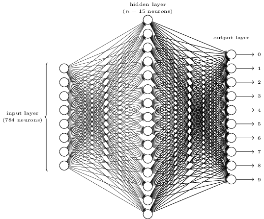

### Cost Function

or the simple version:

$J(\Theta)= -\frac{1}{m} \sum^m_i \sum^{10}_k y^{(i)}_{k}log f_\theta (a^{(i)})_{k}$

### Back Propagation

From the cost function $J(\Theta)$, we have the derivatives of $\Theta^{(1)}$ and $\Theta^{(2)}$:

$\frac{\partial J(\Theta)}{\partial \Theta^{(2)}} = \frac{\partial f_{\theta}(a^{(2)})}{\partial a^{(2)}} \frac{\partial a^{(2)}}{\partial \Theta^{(2)}}$

$\frac{\partial J(\Theta)}{\partial \Theta^{(2)}} = (y-f_{\theta}(a^{(2)}))^Tz^{(1)}$

$\frac{\partial J(\Theta)}{\partial \Theta^{(1)}} = \frac{\partial f_{\theta}(a^{(2)})}{\partial a^{(2)}} \frac{\partial a^{(2)}}{\partial \Theta^{(2)}} \frac{\partial f_{\theta}(a^{(1)})}{\partial a^{(1)}} \frac{\partial a^{(1)}}{\partial \Theta^{(1)}}$

$\frac{\partial J(\Theta)}{\partial \Theta^{(1)}} = \frac{\partial J(\Theta)}{\partial \Theta^{(2)}} \frac{\partial f_{\theta}(a^{(1)})}{\partial a^{(1)}} X^{(0)}$

Here is the R code for the neural network. This model include 25 units in the hidden layer. $J(\Theta)$ can be minimize by gradient descent, called back-propagation in the setting.

```r
NN_cost = function(data, y, init, h_layer=25, lambda=0, num_labels=10) {

  m = nrow(data)
  # reshape Theta1 and Theta2
  in_layer = ncol(data)
  par_t1 = init[c(1:((in_layer+1)*h_layer))]

  par_t2 = init[c(((in_layer+1)*h_layer+1):length(init))]
  Theta1 = matrix(par_t1,h_layer,in_layer+1)
  Theta2 = matrix(par_t2,num_labels,h_layer+1)


  a1 = cbind(1,data)
  z2 = a1%*%t(Theta1)
  a2 = cbind(1,sigmoid(z2))
  z3 = a2%*%t(Theta2)
  h = sigmoid(z3)

  ny = matrix(0, length(y),num_labels)
  for (i in 1:length(y)){
    ny[i,y[i]] = 1
  }

  regu = lambda*(sum(Theta1[,-1]^2)+sum(Theta2[,-1]^2))/(2*m)
  cost = -sum(ny*log(h)+(1-ny)*log(1-h))/m+regu

  delta3 = h-ny
  delta2 = (delta3%*%Theta2[,-1])*sigmoidGradient(z2)

  thres1 = matrix(1,nrow(Theta1),ncol(Theta1))
  thres1[,1] = 0
  thres2 = matrix(1,nrow(Theta2),ncol(Theta2))
  thres2[,1] = 0

  Theta1_grad = (t(delta2)%*%a1)/m + thres1*Theta1*lambda/m
  Theta2_grad = (t(delta3)%*%a2)/m + thres2*Theta2*lambda/m

  result = list(cost=cost,h=h,grad=list(t1=Theta1_grad,t2=Theta2_grad))
  return(result)
}
```

## Train The Model

First, we randomly select 70% of data as training data set.

```r
data_all <- read.csv("train.csv", header=TRUE)
train_size = floor(0.7*nrow(data_all))
train_indx = sample(seq_len(nrow(data_all)), size = train_size)
```

Preprocess and normalize data.

```r
data = data_all[train_indx,]
train = data[,-1]
train = data.matrix(train)
y = data$label
y=replace(y,y==0,10)
train_nl = (train-125)/255
```

Build up the initial value and training variables.

```r
h_layer=25
t1_epsilon = sqrt(6)/sqrt(ncol(train)+h_layer)
t2_epsilon = sqrt(6)/sqrt(h_layer+10)
t1_random = matrix(runif((ncol(train)+1)*25,0,1),25,(ncol(train)+1))
t2_random = matrix(runif(26*10,0,1),10,26)
t1_random = t1_random*2*t1_epsilon - t1_epsilon
t2_random = t2_random*2*t2_epsilon - t2_epsilon
ini = c(as.vector(t1_random),as.vector(t2_random))
lambda=1
costFunction = function(p) {
  result = NN_cost(train_nl,y,p,lambda=lambda)
  J = result$cost
  grad = c(as.vector(result$grad$t1),as.vector(result$grad$t2))
  grad = as.matrix(grad,length(grad),1)
  return(list(J=J,grad=grad))
}
```

Optimize the model

```r
optimization = fmincg(f=costFunction, X=par, Maxiter=500)
```

At the end, I use $fmincg$ function to do the optimization. Because $fmincg$ function is more efficient than my own gradient decent function. $fmincg$ is one of the optimization function Andrew Ng used in his online course [Machine Learning](https://www.coursera.org/course/ml). This function was original written in Matlab, I rewrite it into R. Here are the R code for $fmincg$ function.

```r
fmincg = function(f,X, Maxiter=10) {
  length = Maxiter
  RHO = 0.01
  SIG = 0.5
  INT = 0.1
  EXT = 3.0
  MAX = 20
  RATIO = 100
  red = 1

  i = 0
  ls_failed = 0
  fX = numeric(0)
  eval = f(X)
  f1 = eval$J
  df1 = eval$grad
  i = i + (length<0)
  s = -df1
  d1 = t(-s)%*%s
  z1 = red/(1-d1)

  while (i < abs(length)) {
    i = i + (length>0)
    X0 = X; f0 = f1; df0 = df1
    X = X + z1[1]*s
    eval = f(X)
    f2 = eval$J
    df2 = eval$grad
    i = i + (length<0)
    d2 = t(df2)%*%s;
    f3 = f1; d3 = d1; z3 = -z1;
    if(length>0){M=MAX}else{M=min(MAX,-length-i)}
    success = 0; limit = -1;
    while(1){
      while(((f2 > f1+z1*RHO*d1) | (d2 > -SIG*d1)) & (M > 0)) {
        limit = z1
        if (f2 > f1){
          z2 = z3 - (0.5*d3*z3*z3)/(d3*z3+f2-f3)
        } else {
          A = 6*(f2-f3)/z3+3*(d2+d3)
          B = 3*(f3-f2)-z3*(d3+2*d2)
          z2 = (sqrt(B*B-A*d2*z3*z3)-B)/A}
        if (is.na(z2)|is.infinite(z2)){z2 = z3/2}
        z2 = max(min(z2, INT*z3),(1-INT)*z3)
        z1 = z1 + z2
        X = X + z2[1]*s
        eval = f(X)
        f2 = eval$J
        df2 = eval$grad
        M = M - 1; i = i + (length<0)
        d2 = t(df2)%*%s
        z3 = z3 - z2
      }
      if (f2 > (f1+z1*RHO*d1) | d2 > -SIG*d1) {
        break
      } else if (d2 > SIG*d1) {
        success = 1; break
      } else if (M ==0) {
        break
      }
      A = 6*(f2-f3)/z3+3*(d2+d3)
      B = 3*(f3-f2)-z3*(d3+2*d2)
      z2 = -d2*z3*z3/(B+sqrt(B*B-A*d2*z3*z3))
      if (is.na(z2)|is.infinite(z2)|z2<0) {
        if (limit <-0.5) {
          z2 = z1*(EXT-1)
        } else {
          z2 = (limit-z1)/2
        }
      } else if ((limit > -0.5) & ((z2+z1) > limit)){
        z2 = (limit-z1)/2
      } else if ((limit < -0.5) & ((z2+z1) > z1*EXT)) {
        z2 = z1*(EXT-1)
      } else if (z2 < (-z3*INT)) {
        z2 = -z3*INT
      } else if ((limit > -0.5) & (z2 < (limit-z1)*(1.0-INT))) {
        z2 = (limit - z1)*(1 - INT)
      }
      f3 = f2; d3 = d2; z3 = -z2;
      z1 = z1 + z2; X = X + z2[1]*s;
      eval = f(X)
      f2 = eval$J
      df2 = eval$grad
      M = M - 1; i = i + (length<0)
      d2 = t(df2)%*%s
    }

    if (success) {
      f1 = f2; fX = rbind(fX, f1)
      print(cat('Iteration  ',i,'| Cost:',f1))
      temp = (t(df2)%*%df2-t(df1)%*%df2)/(t(df1)%*%df1)
      s = temp[1]*s - df2
      tmp = df1; df1 = df2; df2 = tmp;
      d2 = t(df1)%*%s
      if (d2>0) {
        s = -df1
        d2 = -t(s)%*%s
      }
      z1 = z1 * min(RATIO, d1/(d2-2.2251e-308))
      d1 = d2
      ls_failed = 0
    } else {
      X = X0; f1 = f0; df1 = df0;
      if (ls_failed|i > abs(length)) {
        break
      }
      tmp = df1; df1 = df2; df2 = tmp;
      s = -df1
      d1 = -t(s)%*%s
      z1 = 1/(1-d1)
      ls_failed = 1
    }
  }
  return(list(par=X,cost=fX))
}
```

## Training Result

The result is achieve by training this model with 29400 data in 200000 iteration.

```r
first_try = fmincg(f=costFunction, X=ini, Maxiter=200000)
```

$ckeck_accurate$ function is build up to check the accurate of my model ues testing data set and validation data set.

```r
check_accurate = function(data, y, t, h_layer=25,lambda,num_labels=10) {
  fit_model = NN_cost(data,y,init=t,h_layer,lambda=lambda,num_labels)
  fit_matirx = fit_model$h
  fit_values = apply(fit_matirx,1,which.max)
  fit_values = as.vector(fit_values)
  y = as.vector(y)
  accurate = sum(fit_values==y)/length(y)
  result = list(fit = fit_values, acu = accurate)
  return(result)
}
```

The rest of the data is been seperate as test set and validate set

```r
test_valid_data = data_all[-train_indx,]
test_size = floor(0.7*nrow(test_valid_data))
test_ind = sample(seq_len(nrow(test_valid_data)), size = test_size)
test_data = test_valid_data[test_ind,]
valid_data = test_valid_data[-test_ind,]
```

Setting up the test set and ckeck the accurate.

```r
test = test_data[,-1]
test = data.matrix(test)
test_y = test_data$label
test_y = replace(test_y,test_y==0,10)
test_nl = (test-125)/255

test_accurate = check_accurate(test_nl,test_y,par,lambda=lambda)
test_accurate$acu
```

[output not shown]

## Refference

- [Stanford University Machine Learning online course](https://www.coursera.org/course/ml)
- The Elements of Statistical Learning, Data Mining, Inference, and Prediction
- Machine Learning An Algorithmic Perspective
- Neural Networks and Statistical Learning